# Working with Data - Assignment 1

### **Dublin Property Trends: 2007 - 2016**

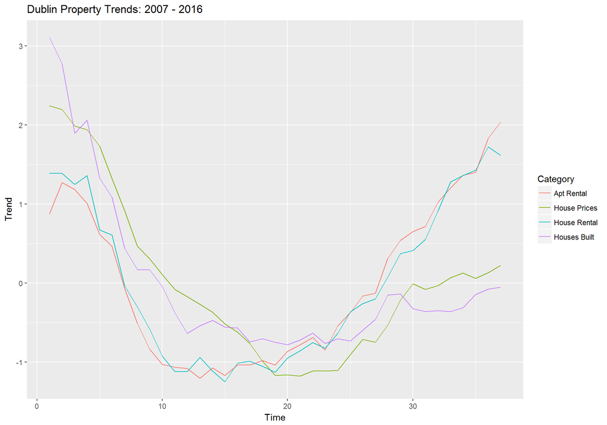

### **Dublin Bikes**

2.1 When having a brief conversation with the manager of Dublin bikes, the following information such as total number of bike stations, stations with or without baking facility, total bike stands across all the stations and how many are available in them and available bikes available will be some of the interesting points he would be interested to know.Also, he would want to know the busiest stations among all the stations. According to Dublin app if there is less or no space available to park bikes, then it is considered busy and based on this information busy stations has been tried to find out.

| Information | Count |
| --- | --- |
| Total bike stations in Dublin | 100 |
| Number of stations with banking facility | 35 |
| Number of stations without banking facility | 65 |
| Total bike stands across all bike stations | 3131 |
| Available bike stands | 1763 |
| Available bikes | 1362 |
| Average available stands | 18 |
| Average available bikes | 14 |

|  | name | address | banking | bike_stands | available_bike_stands | available_bikes |
| --- | --- | --- | --- | --- | --- | --- |
| 1 | SMITHFIELD NORTH | Smithfield North | TRUE | 30 | 0 | 30 |
| 14 | GRANTHAM STREET | Grantham Street | TRUE | 30 | 0 | 30 |
| 16 | PORTOBELLO ROAD | Portobello Road | TRUE | 30 | 0 | 30 |
| 32 | KING STREET NORTH | King Street North | FALSE | 30 | 0 | 30 |
| 41 | CHARLEMONT PLACE | Charlemont Street | FALSE | 40 | 4 | 35 |
| 47 | NORTH CIRCULAR ROAD | North Circular Road | TRUE | 30 | 0 | 30 |
| 56 | PORTOBELLO HARBOUR | Portobello Harbour | FALSE | 30 | 0 | 30 |
| 65 | YORK STREET WEST | York Street West | FALSE | 40 | 3 | 37 |
| 66 | ST. STEPHEN’S GREEN SOUTH | St. Stephen’s Green South | TRUE | 30 | 1 | 29 |
| 70 | ECCLES STREET | Eccles Street | FALSE | 20 | 0 | 20 |
| 80 | GRATTAN STREET | Grattan Street | FALSE | 23 | 0 | 23 |
| 82 | BOLTON STREET | Bolton Street | FALSE | 20 | 2 | 18 |
| 86 | WILTON TERRACE | Wilton Terrace | TRUE | 20 | 0 | 20 |

2.2 Suppose I want to take a bike to go to a friend’s place and I do not want to rely on the bus for the entire journey to save time. So I want to check the stations where there are atleast 15 bikes available, so that I am sure that by the time I will reach that station I will still have bikes available for me. Also, due to the system of dublin bikes I will need to park somewhere as well, so I will also like to see the stations where there are sufficient number of bike stands available.So a data frame is obtained firs considering this in mind. Then a graph is plotted filtering on the basis of banking available at the station or not, as this is also an important aspect for me to know as I am not sure of the available balance in my leap card.

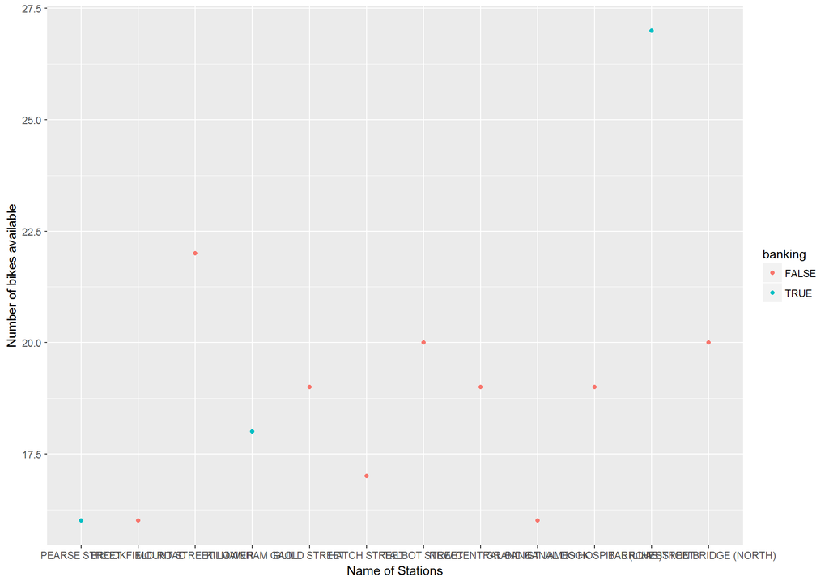

### **Dublin Bus**

Dublin bus is huge transportation network in Dublin, used by almost every class and category of people. There can be many interesting points to know about this network. But before performing the exploratory data analysis, dataset was downloaded from the dublin bus website, viewed to find the tables of interest and then joined to use the information in a meaningful manner and obtain answers to relevant questions.

```
## Total number of stops in Dublin 4724
```

```
## Total number of stops in each area
```

| stop_name | total_stops |
| --- | --- |
| Blessington Rd | 79 |
| Malahide Road | 64 |
| Howth Road | 51 |
| Dublin Rd | 49 |
| Grange Road | 48 |
| Swords Road | 46 |

```
## Number of buses available from each area
```

| stop_name | no_of_buses_accessible |
| --- | --- |
| Malahide Road | 26128 |
| Swords Road | 21305 |
| Stillorgan Road | 21204 |
| Navan Road | 12729 |
| Lucan Road | 12624 |
| Howth Road | 10963 |

```
## # A tibble: 119 x 4
## # Groups:   route_id [119]
##       route_id                                            route_long_name
##          <chr>                                                      <chr>
##  1  0-33-b12-1                      St. Paul's Crescent - Irish Life Mall
##  2 0-33X-b12-1                      Barnageeragh Road - Huguenot Cemetery
##  3  0-65-b12-1                            Valleymount Road - Hawkin House
##  4 0-84X-b12-1                                    Sea Road - Fleet Street
##  5 0-67X-b12-1               Salesian College - University College Dublin
##  6  0-84-b12-1                                   Sea Road - Frascati Road
##  7 0-66X-b12-1                      Kingsbury - University College Dublin
##  8  0-13-b12-1                                 Business Park - Bus Garage
##  9 0-220-b12-1                              FÁS Centre - Shangan Crescent
## 10  0-86-b12-1 Cholaiste Mhuire - Rochestown Avenue Opposite Granitefield
## # ... with 109 more rows, and 2 more variables: min_dist_traveled <dbl>,
## #   max_dist_traveled <dbl>
```

```
## Minimum and Maximum distance travelled by bus on each route
```

| route_id | route_long_name | min_dist_traveled | max_dist_traveled |
| --- | --- | --- | --- |
| 0-1-b12-1 | Strand Road - Shanard Avenue | 6126.444 | 12255.355 |
| 0-102-b12-1 | Bus Interchange - DART Station | 12955.038 | 24678.458 |
| 0-104-b12-1 | Shanard Avenue - Bus Garage | 11243.852 | 11587.170 |
| 0-11-b12-1 | Corrig Road - St. Pappin’s Green | 5721.017 | 18600.589 |
| 0-111-b12-1 | Train Station - Loughlinstown Wood | 7267.752 | 7381.186 |
| 0-114-b12-1 | Train Station - Simons Ridge | 9632.079 | 10063.207 |

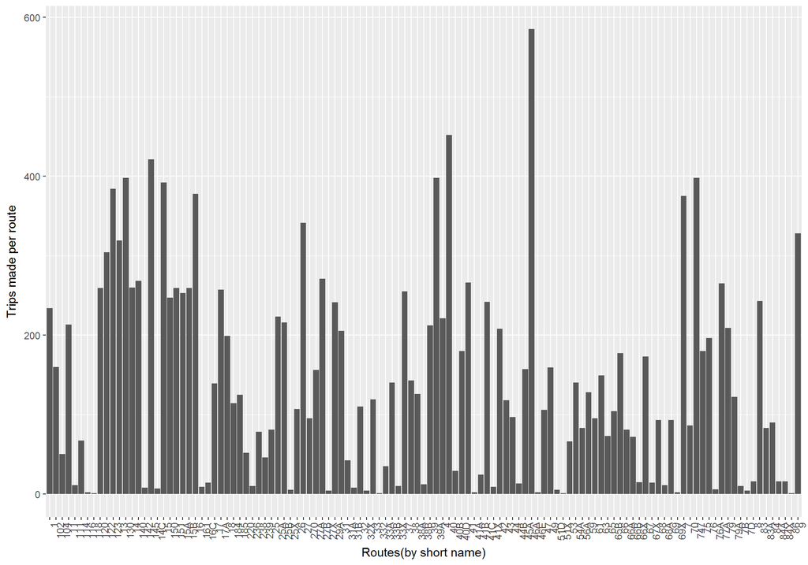

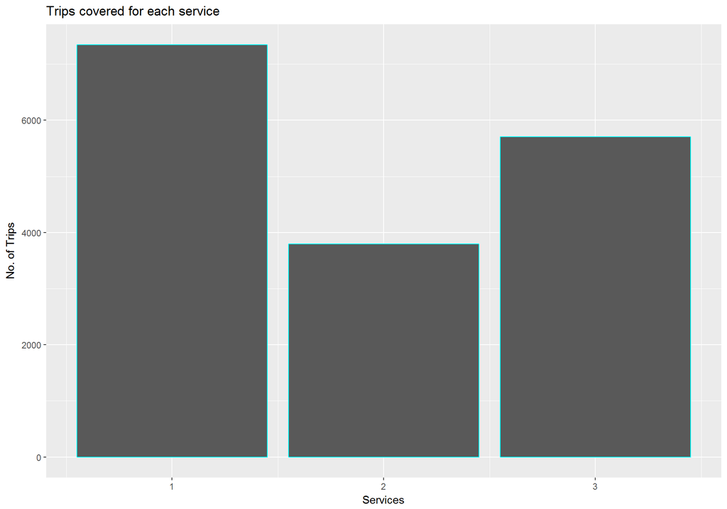

3.2 The route I have selected is 39A(Hansfield Road - University College Dublin) as this is the route I take everyday to commute from my home to college. To become an expert on this route I would like to answer following questions.

```
## Number of buses arriving and departing from each area
```